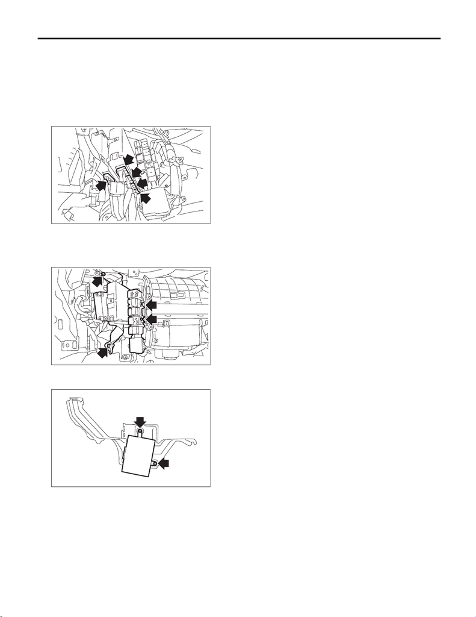

Engine Control Module (ECM)

FUEL INJECTION (FUEL SYSTEMS)

19.Engine Control Module (ECM)

A: REMOVAL

1) Disconnect the ground cable from battery.

2) Remove the glove box. <Ref. to EI-63, REMOV-

AL, Glove Box.>

3) Disconnect the connectors from the ECM and

driver’s control center differential control module.

4) Push down the claws, and remove the relay

block.

5) Remove the bolts and nuts, and remove the

ECM.

6) Remove the driver’s control center differential

control module.

B: INSTALLATION

Install in the reverse order of removal.

CAUTION:

• When the ECM of model with immobilizer has

been replaced, be sure to perform the registra-

tion of immobilizer system. (Refer to the “REG-

ISTRATION MANUAL FOR IMMOBILIZER”.)

• If replacing ECM or the bracket, replace both

parts with new parts at a time.

• After installing the bracket to ECM, do not

separate the bracket.

• If the bracket has been installed to ECM in the

wrong direction, replace both parts to new

parts.

NOTE:

When replacing the ECM, be careful not to use the

ECM of wrong specification to avoid any damage

on the fuel injection system.

Tightening torque:

7.5 N·m (0.8 kgf-m, 5.5 ft-lb)

C: INSPECTION

Check that the ECM has no deformation, cracks or

other damages.